# CellPhoneReviews

Harshitha Shabad

2/10/2020

## Description

- “Cell Phone Reviews” Data set is taken from Kaggle. It has 50k rows and 11 columns.
- Kaggle link : https://www.kaggle.com/masaladata/14-million-cell-phone-reviews#phone_user_review_file_1.csv
- It contains user ratings and reviews for different brands of cell phones.
- Reviews given in english language only have been considered for this assignment.
- Below are the variables present in dataset:
  - phone_url: unique identifier of the cell phone
  - date : date when the review/rating was written
  - lang : language of the review
  - country : country where the review was written
  - source : publisher/website where the review was published
  - domain : website link to the publisher
  - scores : core/rating to the cell phone given by the user
  - score_max : maximum score/rating that the user can given
  - extract : brief review of the cell phone
  - author : name of the author who wrote the review
  - product : name/brand of the product

## Libraries

```r
library(tidyverse)
library(dplyr)
library(tidyr)
```

## Read CSV

```r
df <- read_csv(file="CellPhoneReviews.csv")
head(df, 3)
```

```
## # A tibble: 3 x 11
##   phone_url date  lang  country source domain score score_max extract
##   <chr>     <chr> <chr> <chr>   <chr>  <chr>  <dbl>     <dbl> <chr>
## 1 /cellpho~ 5/2/~ en    us      Veriz~ veriz~    10        10 As a d~
## 2 /cellpho~ 4/28~ en    us      Phone~ phone~    10        10 Love t~
## 3 /cellpho~ 5/4/~ en    us      Amazon amazo~     6        10 Adequa~
## # ... with 2 more variables: author <chr>, product <chr>
```

## Summary

- This data set contains only one nuemrical data column which is rating given to the cell phone on a maximum of 10.
- Score data is summarised to observe mean, median, quartiles, min, max etc

```r
summary(df[ ,"score"])
```

```
##      score
##  Min.   : 1.000
##  1st Qu.: 8.000
##  Median :10.000
##  Mean   : 8.742
##  3rd Qu.:10.000
##  Max.   :10.000
##  NA's   :7
```

## Pre processing the dataset

Separated Date(year, Month, Date) to different columns, stored data into new dataframe newdf, as this data is used for analysis by plotting graphs.

```r
newdf <- df %>%
  separate(date, into = c("Month", "Date", "Year"), sep = "/", convert = TRUE)
head(newdf, 3)
```

```
## # A tibble: 3 x 13
##   phone_url Month  Date  Year lang  country source domain score score_max
##   <chr>     <int> <int> <int> <chr> <chr>   <chr>  <chr>  <dbl>     <dbl>
## 1 /cellpho~     5     2  2017 en    us      Veriz~ veriz~    10        10
## 2 /cellpho~     4    28  2017 en    us      Phone~ phone~    10        10
## 3 /cellpho~     5     4  2017 en    us      Amazon amazo~     6        10
## # ... with 3 more variables: extract <chr>, author <chr>, product <chr>
```

## Visualization1

- Score for phones plotted Year wise for each country
- The graph shows people in US gave more number of scores either low or high, People from other english speaking countries gave very less reviews

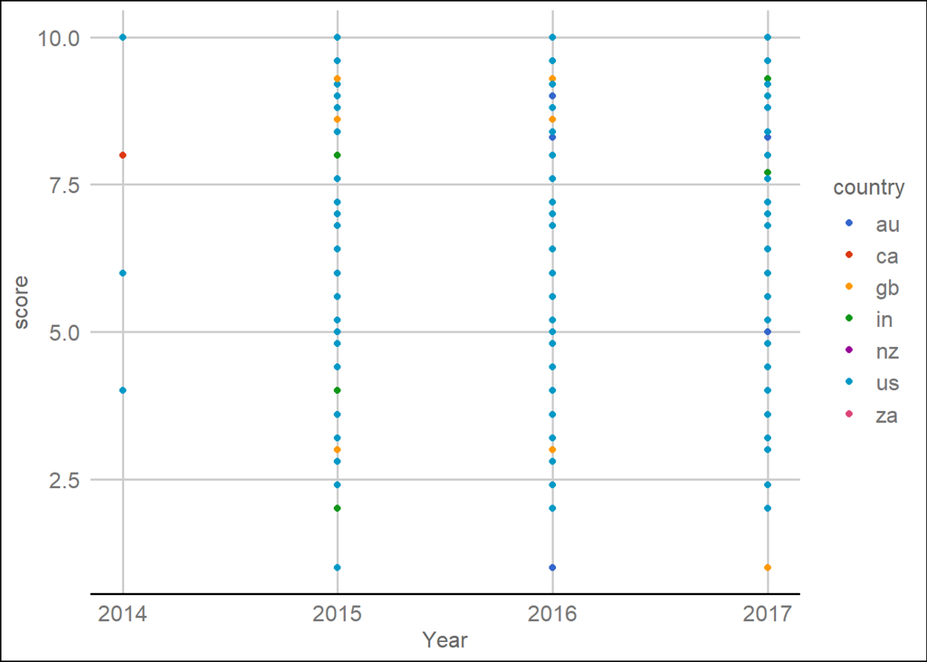

```r
library(ggplot2)
library(ggthemes)
ggplot(data = newdf, mapping = aes(x = Year, y = score, color=country)) +
  geom_point()+
  theme_gdocs()+
  scale_color_gdocs()
```

## Visualization2

- product plotted against country.
- This will tell you which type of phone is getting review from which country.

[figure not shown]

```r
ggplot(data = newdf, mapping = aes(x = product, y = country)) +
  geom_point()+
  theme_gdocs()+
  scale_color_gdocs()
```

## Visualization3

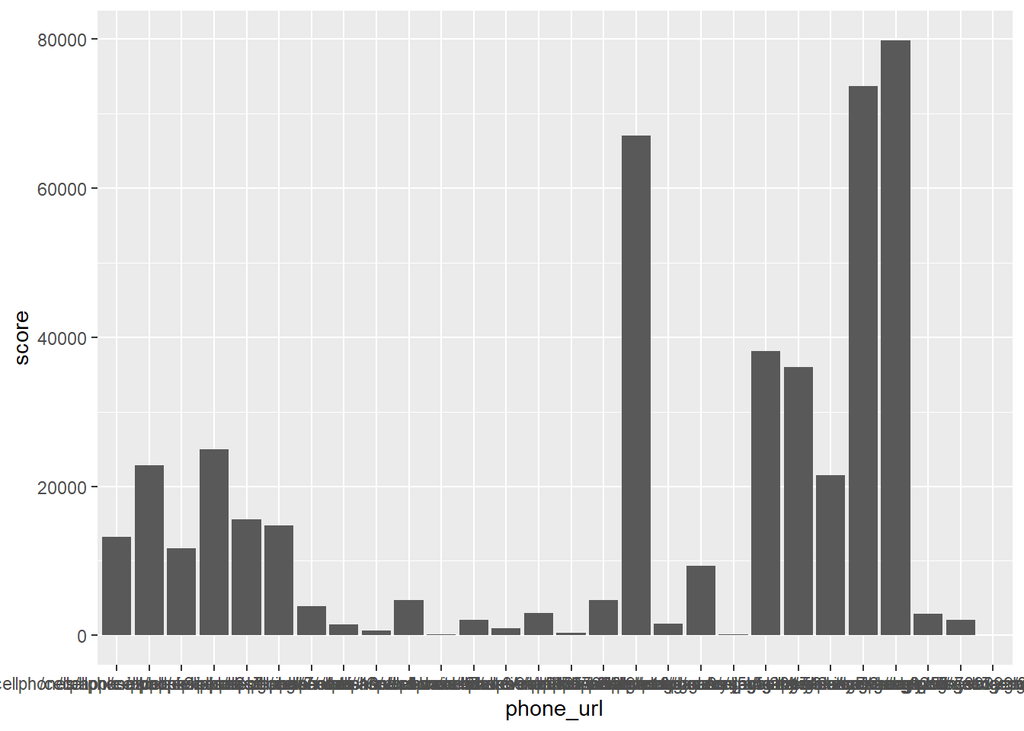

```r
ggplot(data = newdf, aes(x = phone_url, y = score))+
  geom_bar(stat="identity")
```

## NLP

Tokenization - Turn text to tokens

```r
library(tidytext)
library(stringr)
library(tidyverse)
library(dplyr)

df = df %>%
mutate(extract = str_replace_all(extract, "(<br />)+", " ")) %>%
select(extract, score, score_max, date, lang, country,product)
df
```

```
## # A tibble: 52,291 x 7
##    extract            score score_max date  lang  country product
##    <chr>              <dbl>     <dbl> <chr> <chr> <chr>   <chr>
##  1 As a diehard Sams~  10          10 5/2/~ en    us      Samsung Galaxy S8
##  2 Love the phone. t~  10          10 4/28~ en    us      Samsung Galaxy S8
##  3 Adequate feel. Ni~   6          10 5/4/~ en    us      "Samsung Galaxy ~
##  4 Never disappointe~   9.2        10 5/2/~ en    us      Samsung Galaxy S~
##  5 I've now found th~   4          10 5/11~ en    us      Samsung Galaxy S8
##  6 I am the type of ~  10          10 5/10~ en    us      Samsung Galaxy S8
##  7 The way this Sams~   4          10 5/10~ en    us      Samsung Galaxy S8
##  8 I bought this pho~   6          10 5/10~ en    us      Samsung Galaxy S8
##  9 It is an extremel~   6          10 5/10~ en    us      Samsung Galaxy S8
## 10 "Great phone with~   8          10 5/10~ en    us      Samsung Galaxy S8
## # ... with 52,281 more rows
```

```r
tokens <- df %>%
unnest_tokens(output = word, input = extract)
tokens
```

```
## # A tibble: 1,426,730 x 7
##    score score_max date     lang  country product           word
##    <dbl>     <dbl> <chr>    <chr> <chr>   <chr>             <chr>
##  1    10        10 5/2/2017 en    us      Samsung Galaxy S8 as
##  2    10        10 5/2/2017 en    us      Samsung Galaxy S8 a
##  3    10        10 5/2/2017 en    us      Samsung Galaxy S8 diehard
##  4    10        10 5/2/2017 en    us      Samsung Galaxy S8 samsung
##  5    10        10 5/2/2017 en    us      Samsung Galaxy S8 fan
##  6    10        10 5/2/2017 en    us      Samsung Galaxy S8 who
##  7    10        10 5/2/2017 en    us      Samsung Galaxy S8 has
##  8    10        10 5/2/2017 en    us      Samsung Galaxy S8 had
##  9    10        10 5/2/2017 en    us      Samsung Galaxy S8 every
## 10    10        10 5/2/2017 en    us      Samsung Galaxy S8 samsung
## # ... with 1,426,720 more rows
```

Remove stopwords

```r
sw = get_stopwords()
sw
```

```
## # A tibble: 175 x 2
##    word      lexicon
##    <chr>     <chr>
##  1 i         snowball
##  2 me        snowball
##  3 my        snowball
##  4 myself    snowball
##  5 we        snowball
##  6 our       snowball
##  7 ours      snowball
##  8 ourselves snowball
##  9 you       snowball
## 10 your      snowball
## # ... with 165 more rows
```

```r
cleaned_tokens <- tokens %>%
filter(!word %in% sw$word)
```

Remove Numbers

```r
nums <- cleaned_tokens %>%
filter(str_detect(word, "^[0-9]")) %>%
select(word) %>% unique()
nums
```

```
## # A tibble: 1,312 x 1
##    word
##    <chr>
##  1 1st
##  2 2
##  3 5.8
##  4 5.6
##  5 100
##  6 3
##  7 22
##  8 7
##  9 12
## 10 6s
## # ... with 1,302 more rows
```

```r
cleaned_tokens <- cleaned_tokens %>%
filter(!word %in% nums$word)
```

Remove Rare Words

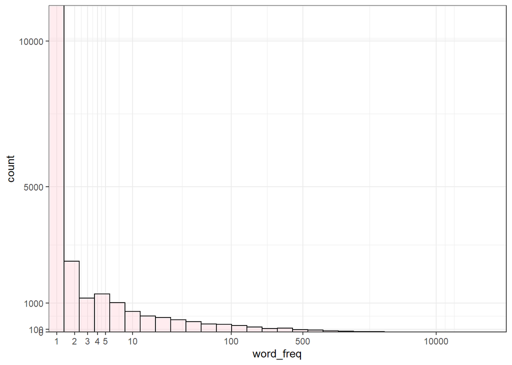

```r
cleaned_tokens %>%
count(word, sort = T) %>%
rename(word_freq = n) %>%
ggplot(aes(x=word_freq)) +
geom_histogram(aes(y=..count..), color="black", fill="pink", alpha=0.3) +
scale_x_continuous(breaks=c(0:5,10,100,500,10e3), trans="log1p", expand=c(0,0)) +
scale_y_continuous(breaks=c(0,100,1000,5e3,10e3,5e4,10e4,4e4), expand=c(0,0)) +
theme_bw()
```

```r
rare <- cleaned_tokens %>%
count(word) %>%
filter(n<10) %>%
select(word) %>% unique()
rare
```

```
## # A tibble: 17,349 x 1
##    word
##    <chr>
##  1 ___
##  2 ____
##  3 __________________________________
##  4 ___________________________________________
##  5 _______________________________________________________________________~
##  6 _______________________________________________________________________~
##  7 _thoroughly_
##  8 _three_
##  9 _ve
## 10 ɑ
## # ... with 17,339 more rows
```

```r
cleaned_tokens <- cleaned_tokens %>%
filter(!word %in% rare$word)
length(unique(cleaned_tokens$word))
```

```
## [1] 3873
```

Word Cloud

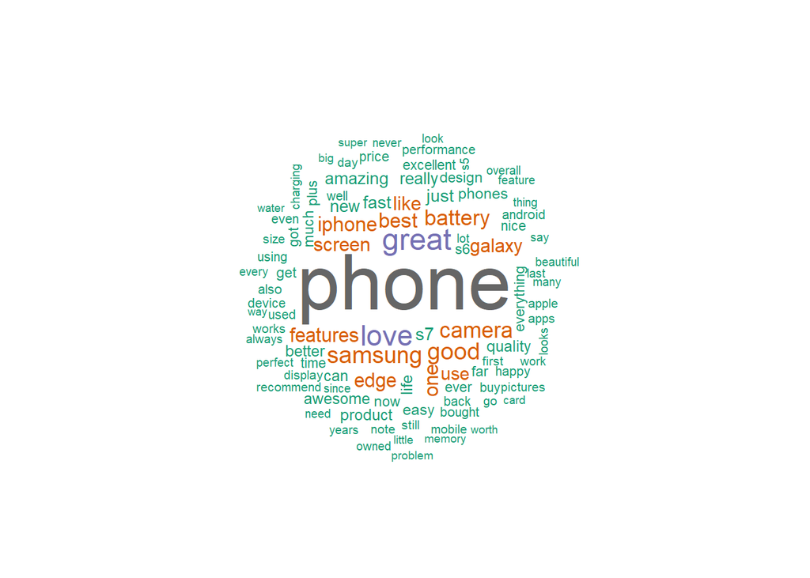

```r
library(wordcloud)
# define a nice color palette
pal <- brewer.pal(8,"Dark2")
# plot the 100 most common words
cleaned_tokens %>%
count(word) %>%
with(wordcloud(word, n, random.order = FALSE, max.words = 100, colors=pal))
```

- From the wordcloud we can say that most of the reviews are about iphone, samsung and about phone battery, screen, camera etc.
- We can also say that most of the words are positive.

Sentiment analysis

```r
sent_reviews = cleaned_tokens %>%
left_join(get_sentiments("nrc")) %>%
rename(nrc = sentiment) %>%
left_join(get_sentiments("bing")) %>%
rename(bing = sentiment) %>%
left_join(get_sentiments("afinn")) %>%
rename(afinn = value)
sent_reviews
```

```
## # A tibble: 867,804 x 10
##    score score_max date   lang  country product    word   nrc   bing  afinn
##    <dbl>     <dbl> <chr>  <chr> <chr>   <chr>      <chr>  <chr> <chr> <dbl>
##  1    10        10 5/2/2~ en    us      Samsung G~ samsu~ <NA>  <NA>     NA
##  2    10        10 5/2/2~ en    us      Samsung G~ fan    <NA>  <NA>      3
##  3    10        10 5/2/2~ en    us      Samsung G~ every  <NA>  <NA>     NA
##  4    10        10 5/2/2~ en    us      Samsung G~ samsu~ <NA>  <NA>     NA
##  5    10        10 5/2/2~ en    us      Samsung G~ phone  <NA>  <NA>     NA
##  6    10        10 5/2/2~ en    us      Samsung G~ since  <NA>  <NA>     NA
##  7    10        10 5/2/2~ en    us      Samsung G~ s      <NA>  <NA>     NA
##  8    10        10 5/2/2~ en    us      Samsung G~ series trust <NA>     NA
##  9    10        10 5/2/2~ en    us      Samsung G~ start~ <NA>  <NA>     NA
## 10    10        10 5/2/2~ en    us      Samsung G~ favor~ joy   posi~     2
## # ... with 867,794 more rows
```

Most common positive and negative words

```r
bing_word_counts <- sent_reviews %>%
filter(!is.na(bing)) %>%
count(word, bing, sort = TRUE)
bing_word_counts
```

```
## # A tibble: 753 x 3
##    word      bing         n
##    <chr>     <chr>    <int>
##  1 good      positive 41725
##  2 love      positive 22966
##  3 great     positive 12597
##  4 happy     positive  8488
##  5 excellent positive  7899
##  6 best      positive  7133
##  7 perfect   positive  6484
##  8 like      positive  5759
##  9 fast      positive  4670
## 10 amazing   positive  4253
## # ... with 743 more rows
```

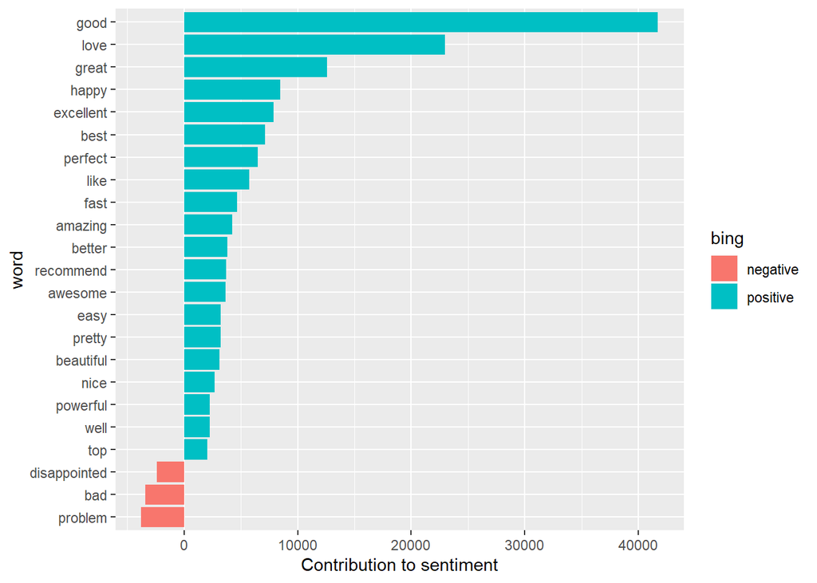

```r
bing_word_counts %>%
filter(n > 2000) %>%
mutate(n = ifelse(bing == "negative", -n, n)) %>%
mutate(word = reorder(word, n)) %>%
ggplot(aes(word, n, fill = bing)) +
geom_col() +
coord_flip() +
labs(y = "Contribution to sentiment")
```

- From above sentiment scores we can say that most of the words in the reviews are positive.
- There are very few words in the reviews which are negative.